```python
from IPython.display import Image
from IPython.core.display import HTML
Image(url= "https://www.noticebard.com/wp-content/uploads/2017/04/christ.jpg", height=50)
```

[output not shown]

# CIA 3

# Programming with Python

# "Human Resources Diversity and Racial Analysis"

#### By,

## Pranav. P

## 1928622

### Submitted to,

## Prof. Kannika Nirai Vaani

#### Human resources is not just about personnel management. A lot of attributes go into an effective HR practice. With globalisation on the rise, the need is now all the more necessary to form conducive and inclusive environments for people to work in organisations. Gender, age, experience, race, creed and other such sociological and physcological factors comes into play while striking a balance in workplace human behaviour. This analysis showcases a glipmse of how such factors play a role in most corporate settings.

#### Data Understanding:

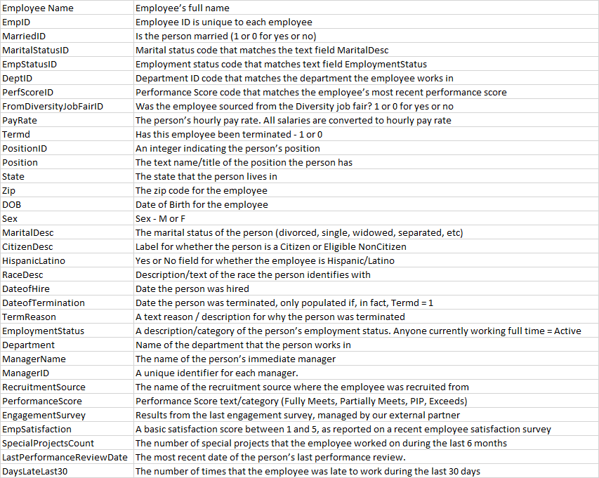

#### Let us begin by importing the necessary libraries. For basic Exploratory Data Analysis, we will need 'matplotlib', 'numpy' and 'pandas'. We will also be using 'seaborn' for statistical visualization.

```python
import numpy as np
import pandas as pd
import matplotlib.pyplot as plt
import seaborn as sns
%matplotlib inline
```

#### The HR dataset is taken from kaggle.com. We will Import the dataset in 'csv' format as it is and store it in a variable 'hr'. We can then see basic information using 'info'.

```python
hr = pd.read_csv('C:\\Users\\lenovo\\Desktop\\COLLEGE\\Christ\\Trimester 4\\Programming with Python\\HR Dataset.csv')
hr.info()
```

```
<class 'pandas.core.frame.DataFrame'>
RangeIndex: 401 entries, 0 to 400
Data columns (total 35 columns):
Employee_Name                 310 non-null object
EmpID                         310 non-null float64
MarriedID                     310 non-null float64
MaritalStatusID               310 non-null float64
GenderID                      310 non-null float64
EmpStatusID                   310 non-null float64
DeptID                        310 non-null float64
PerfScoreID                   310 non-null float64
FromDiversityJobFairID        310 non-null float64
PayRate                       310 non-null float64
Termd                         310 non-null float64
PositionID                    310 non-null float64
Position                      310 non-null object
State                         310 non-null object
Zip                           310 non-null float64
DOB                           310 non-null object
Sex                           310 non-null object
MaritalDesc                   310 non-null object
CitizenDesc                   310 non-null object
HispanicLatino                310 non-null object
RaceDesc                      310 non-null object
DateofHire                    310 non-null object
DateofTermination             103 non-null object
TermReason                    309 non-null object
EmploymentStatus              310 non-null object
Department                    310 non-null object
ManagerName                   310 non-null object
ManagerID                     302 non-null float64
RecruitmentSource             310 non-null object
PerformanceScore              310 non-null object
EngagementSurvey              310 non-null float64
EmpSatisfaction               310 non-null float64
SpecialProjectsCount          310 non-null float64
LastPerformanceReview_Date    207 non-null object
DaysLateLast30                207 non-null float64
dtypes: float64(17), object(18)
memory usage: 109.7+ KB
```

#### Let us see what the dataset holds by listing the first 5 observations:

```python
hr.head(5)
```

|  | Employee_Name | EmpID | MarriedID | MaritalStatusID | GenderID | EmpStatusID | DeptID | PerfScoreID | FromDiversityJobFairID | PayRate | ... | Department | ManagerName | ManagerID | RecruitmentSource | PerformanceScore | EngagementSurvey | EmpSatisfaction | SpecialProjectsCount | LastPerformanceReview_Date | DaysLateLast30 |
| --- | --- | --- | --- | --- | --- | --- | --- | --- | --- | --- | --- | --- | --- | --- | --- | --- | --- | --- | --- | --- | --- |
| 0 | Brown, Mia | 1.103024e+09 | 1.0 | 1.0 | 0.0 | 1.0 | 1.0 | 3.0 | 1.0 | 28.50 | ... | Admin Offices | Brandon R. LeBlanc | 1.0 | Diversity Job Fair | Fully Meets | 2.04 | 2.0 | 6.0 | 1/15/2019 | 0.0 |
| 1 | LaRotonda, William | 1.106027e+09 | 0.0 | 2.0 | 1.0 | 1.0 | 1.0 | 3.0 | 0.0 | 23.00 | ... | Admin Offices | Brandon R. LeBlanc | 1.0 | Website Banner Ads | Fully Meets | 5.00 | 4.0 | 4.0 | 1/17/2019 | 0.0 |
| 2 | Steans, Tyrone | 1.302053e+09 | 0.0 | 0.0 | 1.0 | 1.0 | 1.0 | 3.0 | 0.0 | 29.00 | ... | Admin Offices | Brandon R. LeBlanc | 1.0 | Internet Search | Fully Meets | 3.90 | 5.0 | 5.0 | 1/18/2019 | 0.0 |
| 3 | Howard, Estelle | 1.211051e+09 | 1.0 | 1.0 | 0.0 | 1.0 | 1.0 | 3.0 | 0.0 | 21.50 | ... | Admin Offices | Brandon R. LeBlanc | 1.0 | Pay Per Click - Google | Fully Meets | 3.24 | 3.0 | 4.0 | NaN | NaN |
| 4 | Singh, Nan | 1.307060e+09 | 0.0 | 0.0 | 0.0 | 1.0 | 1.0 | 3.0 | 0.0 | 16.56 | ... | Admin Offices | Brandon R. LeBlanc | 1.0 | Website Banner Ads | Fully Meets | 5.00 | 3.0 | 5.0 | 1/15/2019 | 0.0 |

5 rows × 35 columns

#### Let us determine the dimensions of the dataset using 'shape':

```python
hr.shape
```

```
(401, 35)
```

#### Now, we can see basic statistical inferences from the dataset using 'describe':

```python
hr.describe().transpose()
```

|  | count | mean | std | min | 25% | 50% | 75% | max |
| --- | --- | --- | --- | --- | --- | --- | --- | --- |
| EmpID | 310.0 | 1.199745e+09 | 1.829600e+08 | 6.020003e+08 | 1.101024e+09 | 1.203032e+09 | 1.378814e+09 | 1.988300e+09 |
| MarriedID | 310.0 | 3.967742e-01 | 4.900194e-01 | 0.000000e+00 | 0.000000e+00 | 0.000000e+00 | 1.000000e+00 | 1.000000e+00 |
| MaritalStatusID | 310.0 | 8.096774e-01 | 9.447024e-01 | 0.000000e+00 | 0.000000e+00 | 1.000000e+00 | 1.000000e+00 | 4.000000e+00 |
| GenderID | 310.0 | 4.290323e-01 | 4.957382e-01 | 0.000000e+00 | 0.000000e+00 | 0.000000e+00 | 1.000000e+00 | 1.000000e+00 |
| EmpStatusID | 310.0 | 2.396774e+00 | 1.795533e+00 | 1.000000e+00 | 1.000000e+00 | 1.000000e+00 | 5.000000e+00 | 5.000000e+00 |
| DeptID | 310.0 | 4.606452e+00 | 1.082349e+00 | 1.000000e+00 | 5.000000e+00 | 5.000000e+00 | 5.000000e+00 | 6.000000e+00 |
| PerfScoreID | 310.0 | 2.983871e+00 | 5.771242e-01 | 1.000000e+00 | 3.000000e+00 | 3.000000e+00 | 3.000000e+00 | 4.000000e+00 |
| FromDiversityJobFairID | 310.0 | 9.354839e-02 | 2.916702e-01 | 0.000000e+00 | 0.000000e+00 | 0.000000e+00 | 0.000000e+00 | 1.000000e+00 |
| PayRate | 310.0 | 3.128481e+01 | 1.538362e+01 | 1.400000e+01 | 2.000000e+01 | 2.400000e+01 | 4.531500e+01 | 8.000000e+01 |
| Termd | 310.0 | 3.322581e-01 | 4.717845e-01 | 0.000000e+00 | 0.000000e+00 | 0.000000e+00 | 1.000000e+00 | 1.000000e+00 |
| PositionID | 310.0 | 1.683871e+01 | 6.232272e+00 | 1.000000e+00 | 1.800000e+01 | 1.900000e+01 | 2.000000e+01 | 3.000000e+01 |
| Zip | 310.0 | 6.569732e+03 | 1.693386e+04 | 1.013000e+03 | 1.901250e+03 | 2.132000e+03 | 2.357000e+03 | 9.805200e+04 |
| ManagerID | 302.0 | 1.457947e+01 | 8.090352e+00 | 1.000000e+00 | 1.000000e+01 | 1.500000e+01 | 1.900000e+01 | 3.900000e+01 |
| EngagementSurvey | 310.0 | 3.332097e+00 | 1.290590e+00 | 1.030000e+00 | 2.082500e+00 | 3.470000e+00 | 4.520000e+00 | 5.000000e+00 |
| EmpSatisfaction | 310.0 | 3.890323e+00 | 9.106898e-01 | 1.000000e+00 | 3.000000e+00 | 4.000000e+00 | 5.000000e+00 | 5.000000e+00 |
| SpecialProjectsCount | 310.0 | 1.209677e+00 | 2.352009e+00 | 0.000000e+00 | 0.000000e+00 | 0.000000e+00 | 0.000000e+00 | 8.000000e+00 |
| DaysLateLast30 | 207.0 | 0.000000e+00 | 0.000000e+00 | 0.000000e+00 | 0.000000e+00 | 0.000000e+00 | 0.000000e+00 | 0.000000e+00 |

#### Let us check for missing values in the dataset:

```python
hr.isna().sum()
```

```
Employee_Name                  91
EmpID                          91
MarriedID                      91
MaritalStatusID                91
GenderID                       91
EmpStatusID                    91
DeptID                         91
PerfScoreID                    91
FromDiversityJobFairID         91
PayRate                        91
Termd                          91
PositionID                     91
Position                       91
State                          91
Zip                            91
DOB                            91
Sex                            91
MaritalDesc                    91
CitizenDesc                    91
HispanicLatino                 91
RaceDesc                       91
DateofHire                     91
DateofTermination             298
TermReason                     92
EmploymentStatus               91
Department                     91
ManagerName                    91
ManagerID                      99
RecruitmentSource              91
PerformanceScore               91
EngagementSurvey               91
EmpSatisfaction                91
SpecialProjectsCount           91
LastPerformanceReview_Date    194
DaysLateLast30                194
dtype: int64
```

```python
hr.isnull().values.any()
```

```
True
```

#### We can notice that there are quite a few missing values. In case we proceed to modify the null values by either neglecting them or removing them, there might be a significant increase in bias of the analysis. Since the aim of the project is to determine diversity and ethnic distributions, this may prove to work as a disadvantage. Hence, the data is used as is without any record deletion.

#### Gender diversification among the lot:

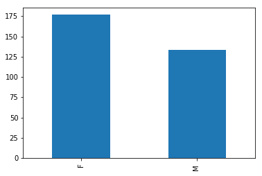

```python
hr['Sex'].value_counts().plot(kind='bar')
```

#### Department wise gender diversification:

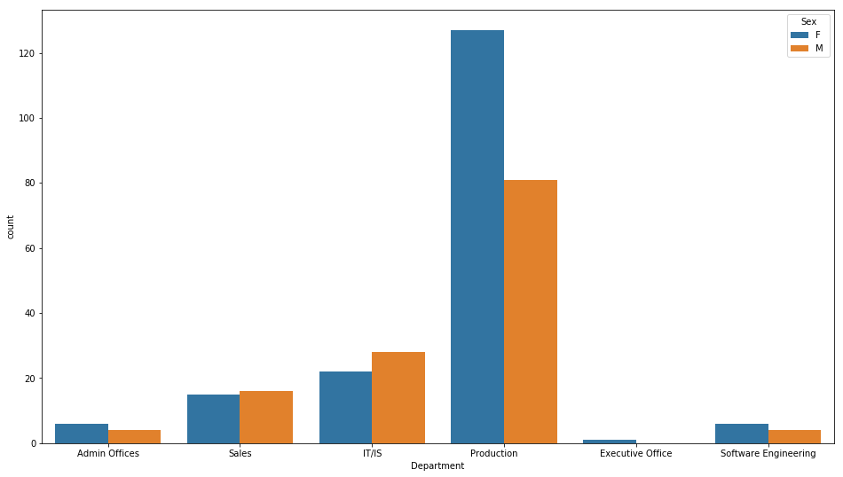

```python
plt.figure(figsize=(16,9))
ax=sns.countplot(x=hr['Department'],hue=hr['Sex'])
```

#### Let us now examine the racial background of the employees in the said dataset:

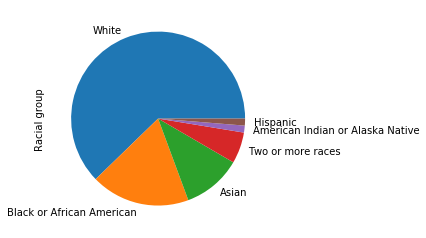

```python
hr['RaceDesc'].value_counts().plot(kind='pie')
```

#### It can be seen that majority of the employees have a 'White' ethnicity. Let us put a number on that by means of a percentage. We must note that the said organisation is based out of the United States of America.

```python
hr.RaceDesc.name = 'Racial group'
display(hr.RaceDesc.value_counts(),
        hr.RaceDesc.value_counts(normalize=True) * 100)
```

```
White                               193
Black or African American            57
Asian                                34
Two or more races                    18
American Indian or Alaska Native      4
Hispanic                              4
Name: Racial group, dtype: int64
```

```
White                               62.258065
Black or African American           18.387097
Asian                               10.967742
Two or more races                    5.806452
American Indian or Alaska Native     1.290323
Hispanic                             1.290323
Name: Racial group, dtype: float64
```

#### According to 2018 data by the U.S Bureau of Labor Statistics, the country's labor force is made of 78% Whites, 13% Blacks and 6% Asians (https://www.bls.gov/opub/reports/race-and-ethnicity/2018/home.htm). Taking that as a baseline, we can say that the company is diverse from a racial standpoint.

#### Let us now see how the relationship status of the employees fare overall:

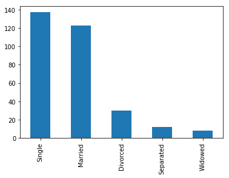

```python
hr['MaritalDesc'].value_counts().plot(kind='bar')
```

#### The dataset contains information on the results of a survey conducted to determine Employee Satisfaction. This can be visualized in the form of a histogram as shown below:

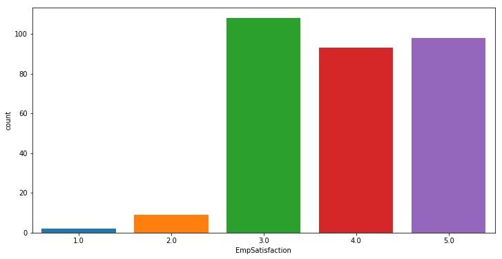

```python
plt.figure(figsize=(12,6))
sns.countplot(x='EmpSatisfaction',data=hr,saturation=1)
```

#### Performance Score is another parameter that each employee is credited with, based on his/her performance. Each employee is mapped to a Manager who in turn assigns a performance score. This can be seen below, where the graph shows performance scores in each department.

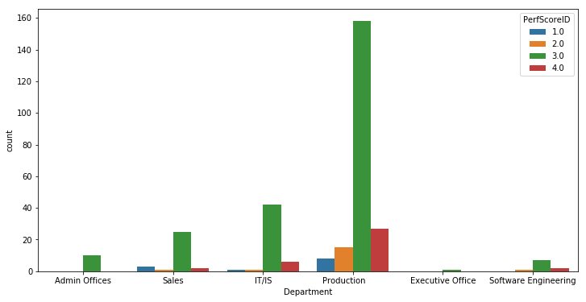

```python
plt.figure(figsize=(12,6))
sns.countplot(data=hr,x='Department',hue='PerfScoreID')
```

#### The ethnic diversity mapped along with the citizenship status of the employees:

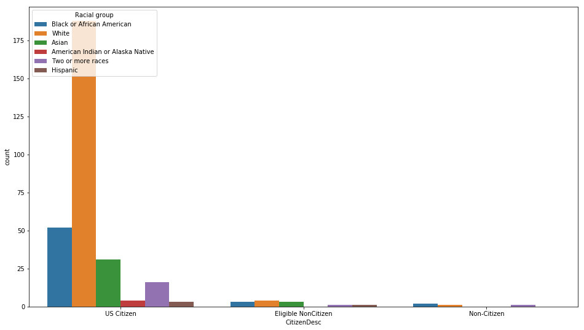

```python
plt.figure(figsize=(16,9))
ax=sns.countplot(x=hr['CitizenDesc'],hue=hr['RaceDesc'])
```

#### Employee status marks the current status of employment for each employee. This is classified as: Active, Terminated for cause, Future Start, Leave of absence and Volunatry termination. We can see that most employees are actively employed in the company.

[figure not shown]

```python
hr['EmploymentStatus'].hist(bins=50)
```

#### There are various positions in the said company. The plot below showcsaes the count of various positions in the company.

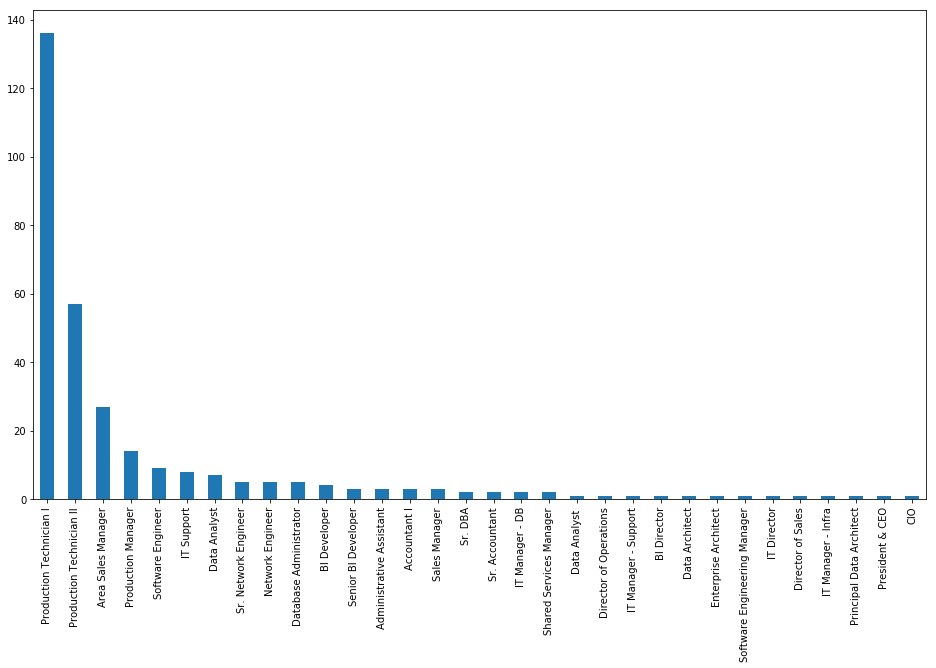

```python
plt.figure(figsize=(16,9))
hr['Position'].value_counts().plot(kind='bar')
```

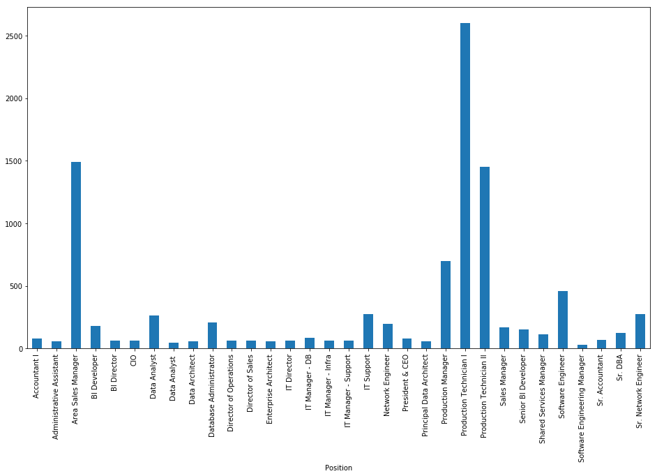

```python
plt.figure(figsize=(16,9))
hr.groupby('Position')['PayRate'].sum().plot(kind='bar')
```

#### The mean, median and atandard deviations of the pay rates are as follows:

```python
hr['PayRate'].describe()
```

```
count    310.000000
mean      31.284806
std       15.383615
min       14.000000
25%       20.000000
50%       24.000000
75%       45.315000
max       80.000000
Name: PayRate, dtype: float64
```

#### Department wise pay rates:

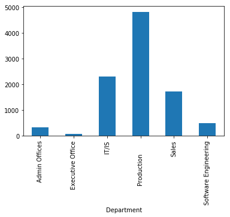

```python
hr.groupby('Department')['PayRate'].sum().plot(kind='bar')
```

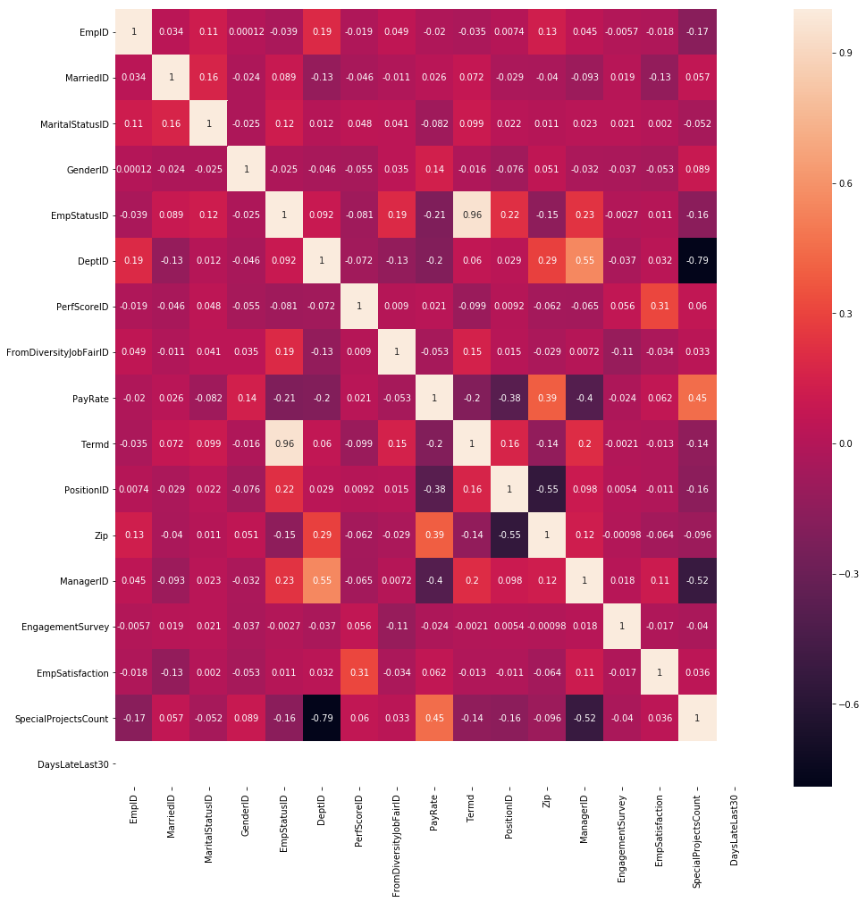

```python
plt.figure(figsize=(16,16))
sns.heatmap(hr.corr(),annot=True)
```

#### Learnings:

1. Data understanding through basic describe functions.
2. Understood the business requirements when it comes to maintaining diversity.
3. Understood various libraries and their usefulness in exploratory data analysis.
4. Basics of storytelling through visualization in python.